# Core Quants Week 13 classwork

YOUR NAME

12/03/2020

Today is about thinking through the examples rather than getting R to work. Therefore, we will address them together, step by step.

**Source**

```r
library(tidyverse)
```

**Message**

**Message**

**Message**

# Predicting coronavirus cases using lm()

Let’s go back to the very start of the Covid-pandemic a year ago. Back then, people in many countries were worried about the virus being brought in by Chinese visitors. But was the number of Chinese tourists to OECD countries related to the number of Covid-19 cases.

**Source**

```r
#Load data
corona <- read_csv(url("https://github.com/LukasWallrich/GoldCoreQuants-materials/raw/main/R%20exercises/data/Chinese_tourists_and_covid19_cases_through_11032020.csv"))
```

**Message**

**Source**

```r
#Let's see if tourist numbers and cases appear linearly related
ggplot(corona, aes(x = Tourists, y = Cases)) +
  geom_point() +
  geom_smooth(method = "lm")
```

**Message**

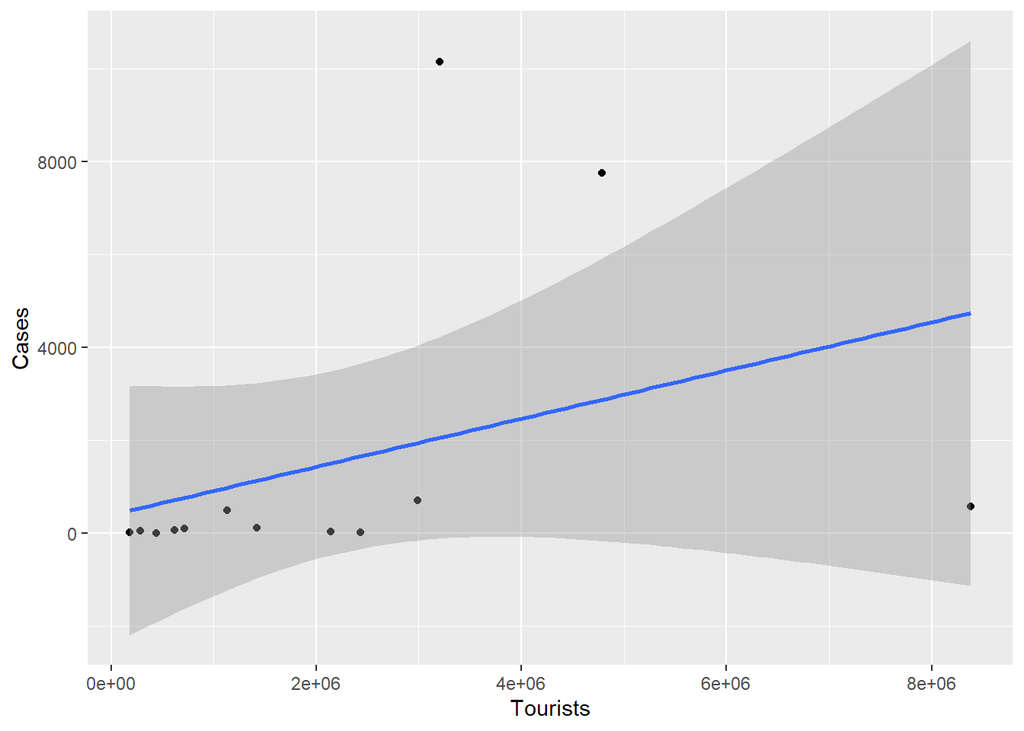

**Source**

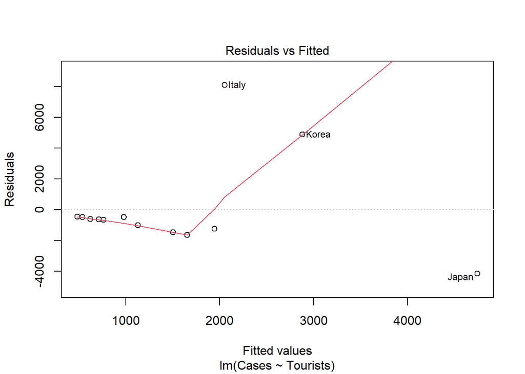

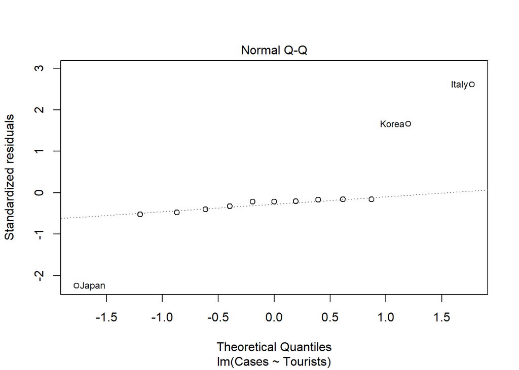

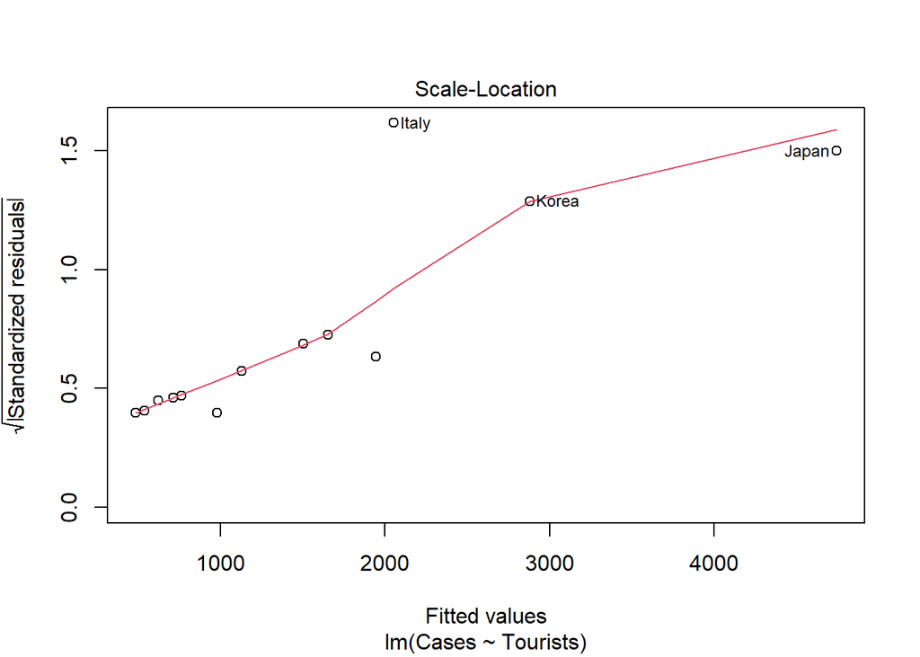

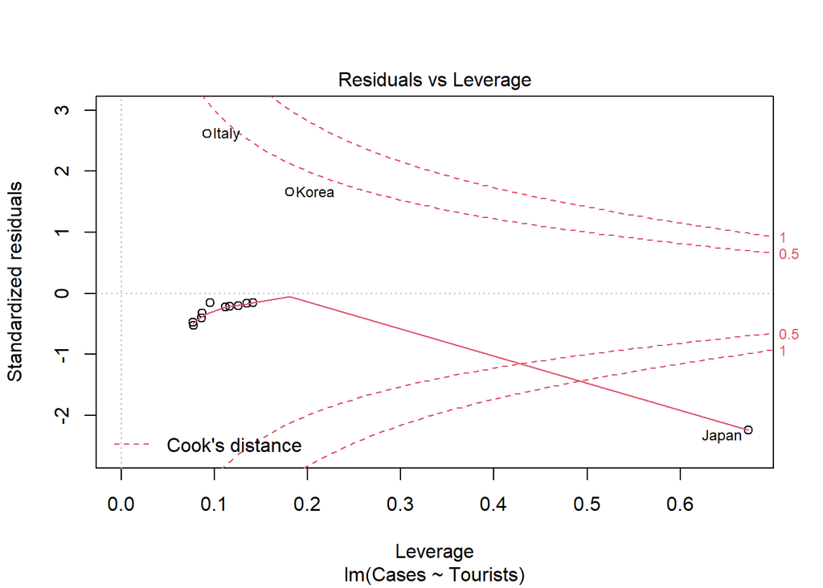

```r
#No need to fit this model, but just to check the plot
fit <- lm(Cases ~ Tourists, corona)
plot(fit, labels.id = corona$Country)
```

**Source**

```r
#Given that diseases spread exponentially, we might expect that Tourists predict log(Cases) - better.
ggplot(corona, aes(x = Tourists, y = log(Cases))) +
  geom_point() +
  geom_smooth(method = "lm")
```

**Message**

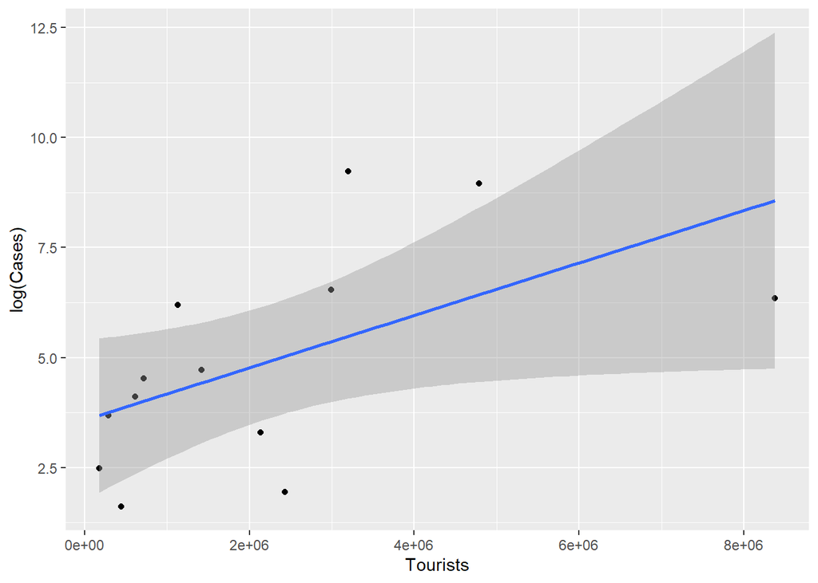

**Source**

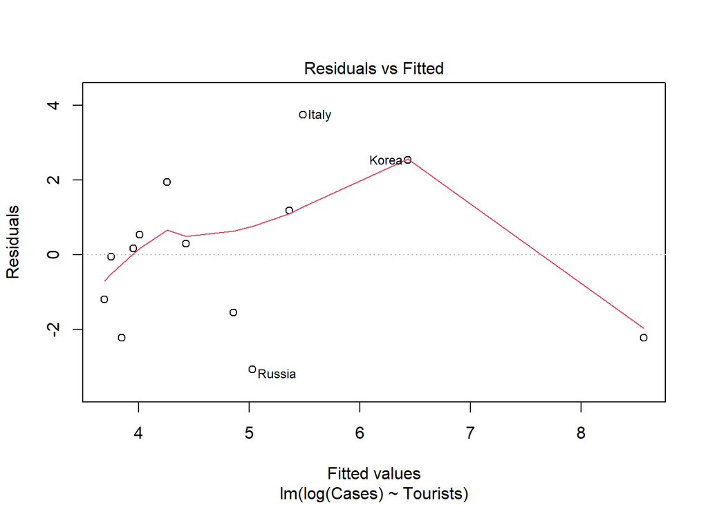

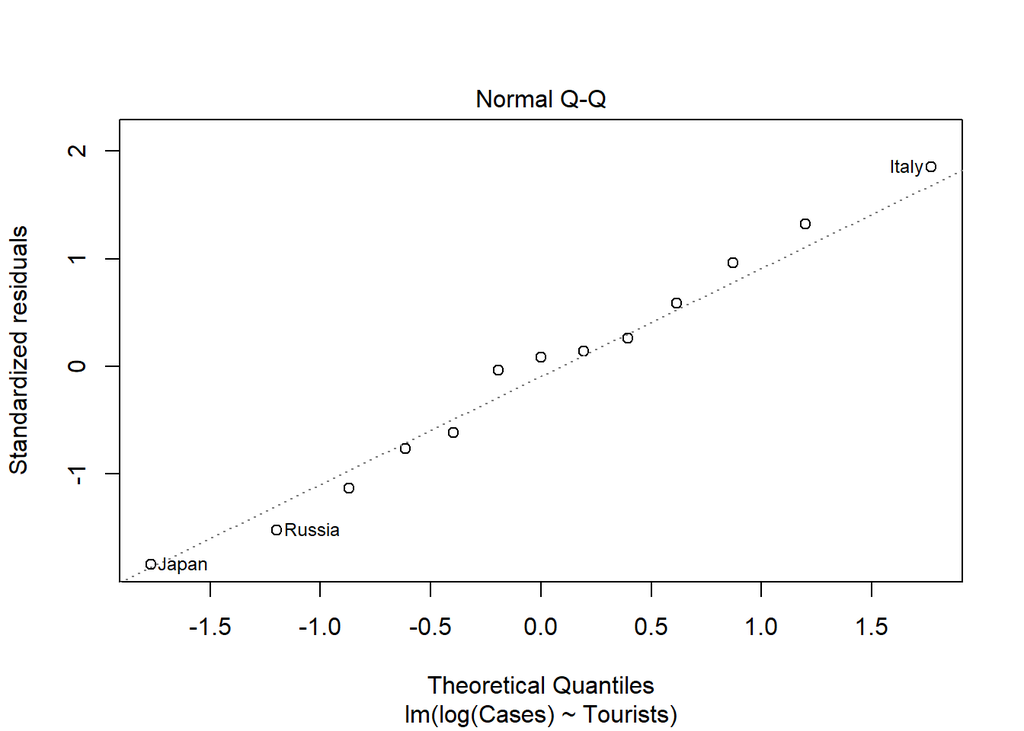

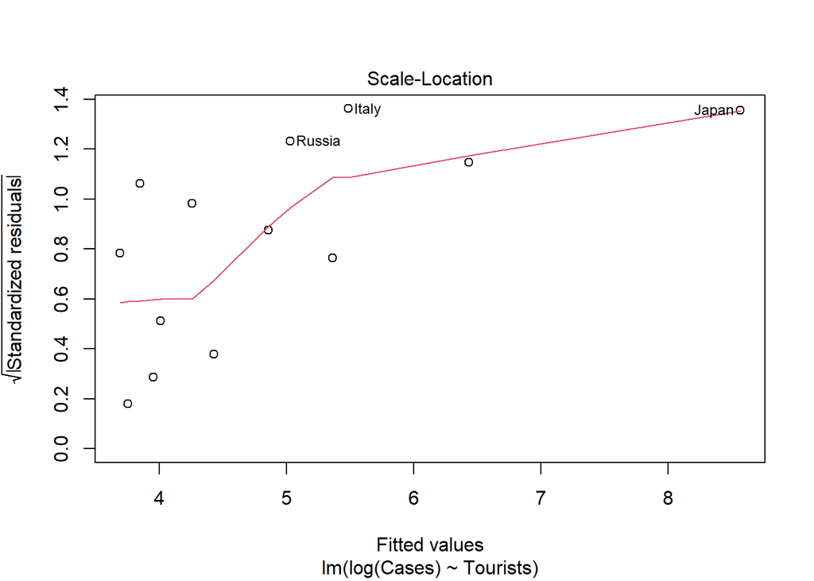

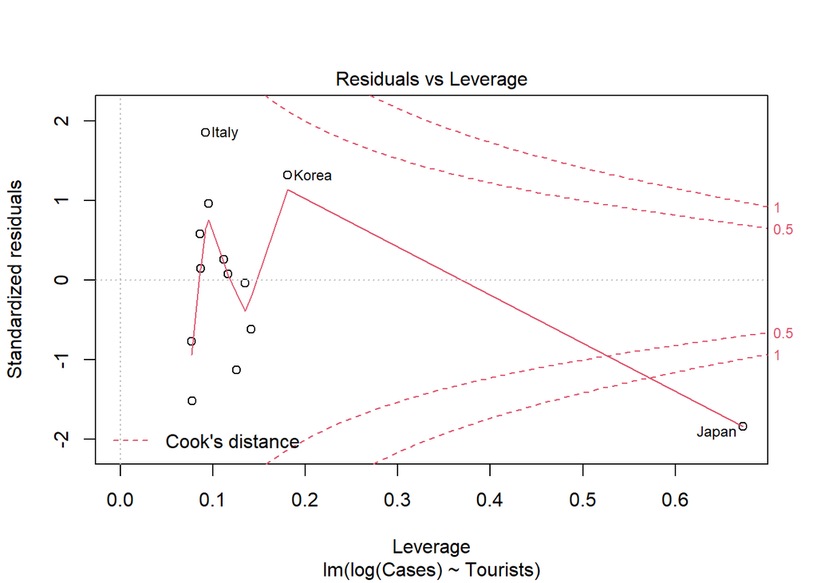

```r
#Fit the model and look at diagnostic plots
fit <- lm(log(Cases) ~ Tourists, corona)
plot(fit, labels.id = corona$Country)
```

**Source**

```r
#Look at plot 4. The key issue here is Japan - an outlier with lots of leverage. A good way to pull variables closer together and thereby reduce the impact of high outliers is a log transformation. Also log-log models are easier to interpret than one log only

#So, let's see how log(Tourists) relate to log(Cases)
ggplot(corona, aes(x = log(Tourists), y = log(Cases))) +
  geom_point() +
  geom_smooth(method = "lm")
```

**Message**

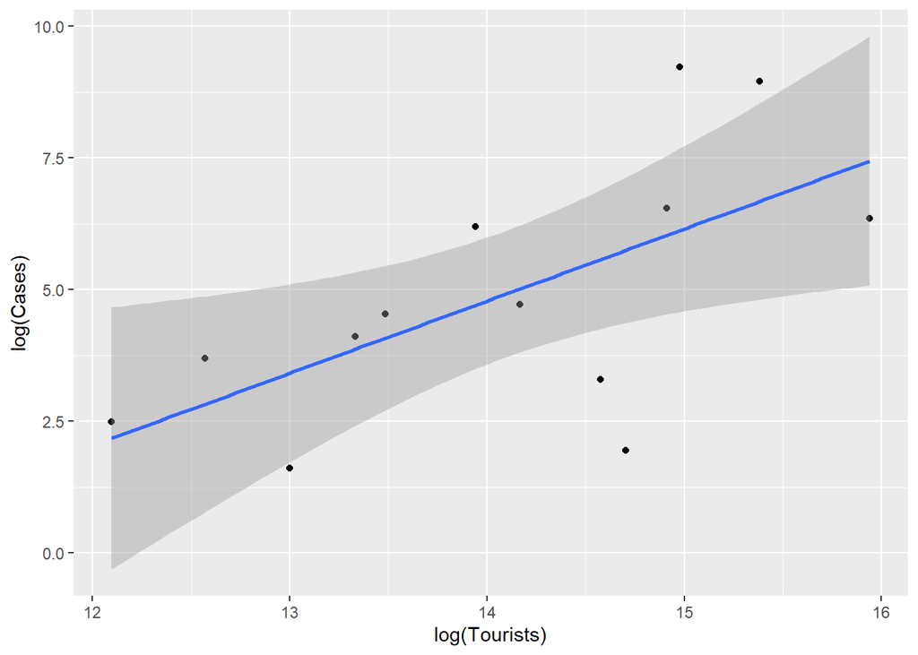

**Source**

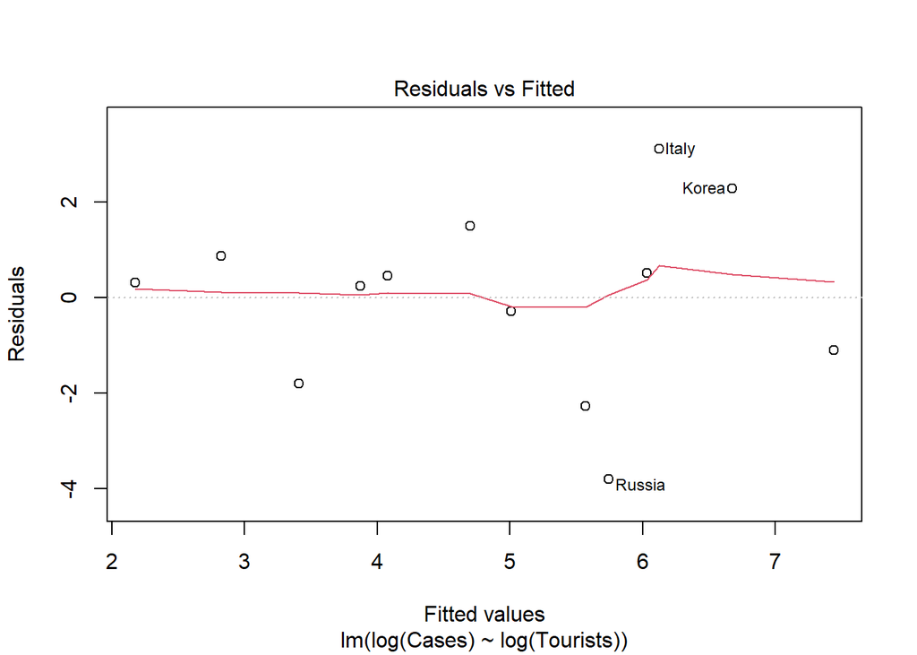

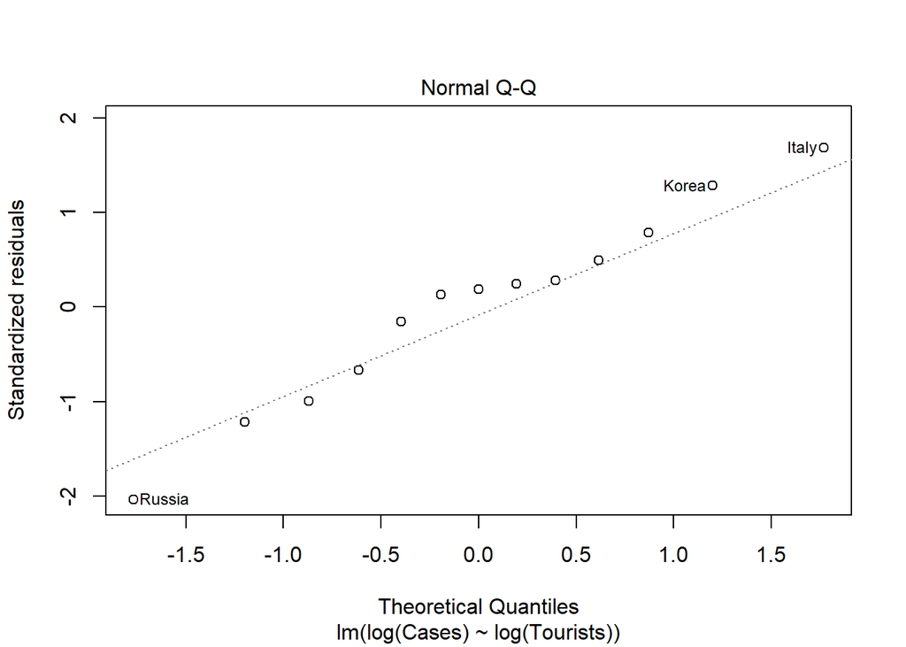

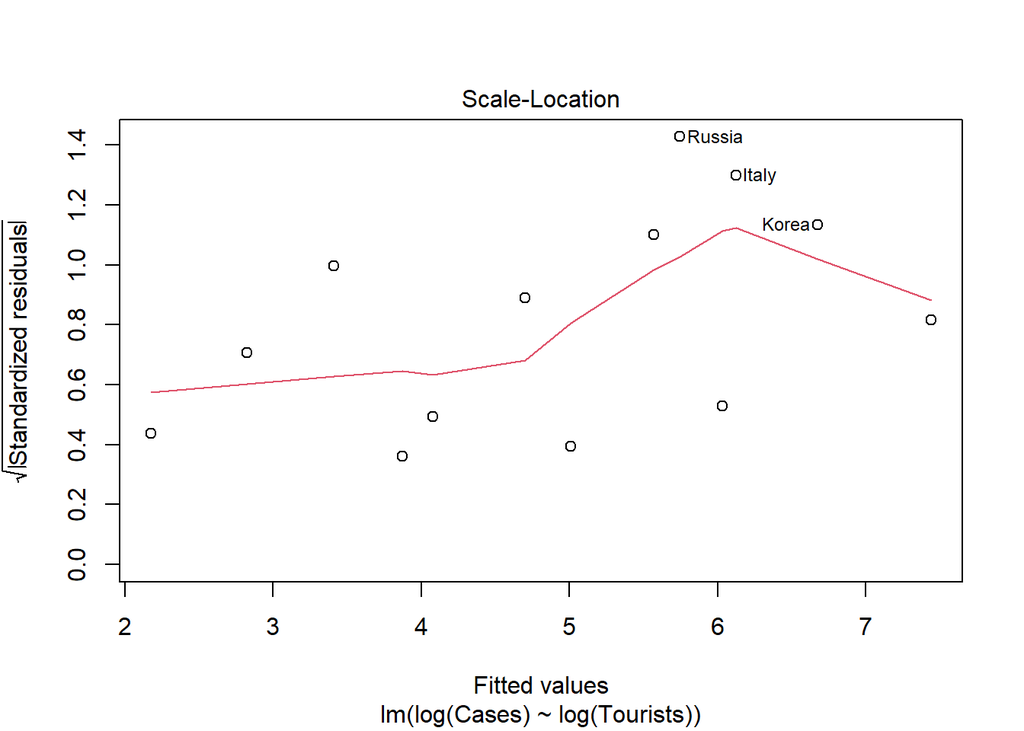

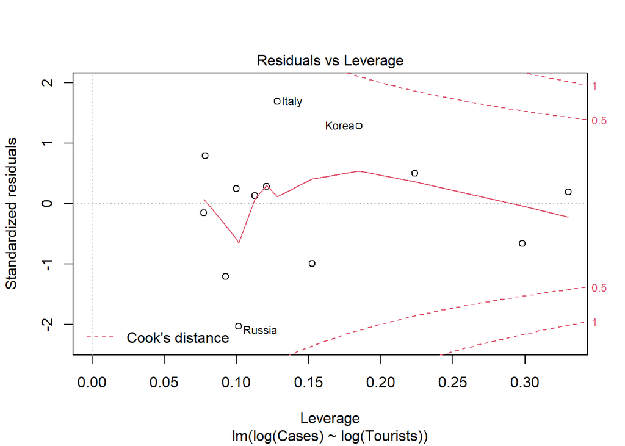

```r
fit <- lm(log(Cases) ~ log(Tourists), corona)
plot(fit, labels.id = corona$Country)
```

**Source**

```r
#This looks better, no more outliers with high leverage.

#For further analysis, we can add the predicted values to the data and calculate the residual for each country
corona <- corona %>% mutate(prediction = predict(fit), residual = log(Cases) - prediction)

#The three strongest outliers (i.e. largest residuals are labeled in the plots)
ggplot(corona, aes(x = log(Tourists), y = log(Cases))) +
  geom_point() +
  geom_smooth(method = "lm") +
  geom_text(data = corona %>%
              slice_max(abs(residual), n = 3),
            mapping = aes(label = Country))
```

**Message**

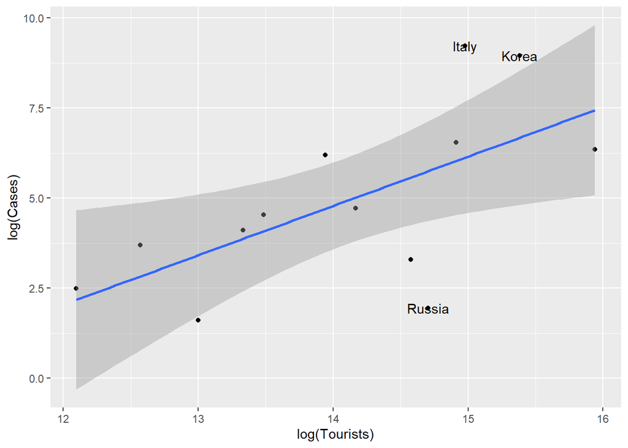

**Source**

```r
#They are Korea, Italy and Russia - Covid already spread locally in Korea and Italy, and Russia might not do enough testing (at least that has been argued based on such models) - so the most interesting result of that model are the outliers

summary(fit)
```

**Output**

```
##
## Call:
## lm(formula = log(Cases) ~ log(Tourists), data = corona)
##
## Residuals:
##     Min      1Q  Median      3Q     Max
## -3.7997 -1.0970  0.3086  0.8642  3.1034
##
## Coefficients:
##               Estimate Std. Error t value Pr(>|t|)
## (Intercept)    -14.381      7.035  -2.044   0.0656 .
## log(Tourists)    1.369      0.498   2.749   0.0189 *
## ---
## Signif. codes:  0 '***' 0.001 '**' 0.01 '*' 0.05 '.' 0.1 ' ' 1
##
## Residual standard error: 1.968 on 11 degrees of freedom
## Multiple R-squared:  0.4072, Adjusted R-squared:  0.3533
## F-statistic: 7.555 on 1 and 11 DF,  p-value: 0.01893
```

**Source**

```r
#How to interpret that correlation coefficient? They can now be interpreted as percentage changes. For each 1%-increase in the number of Chinese tourists, the number of Covid-19 cases is estimated to increase by 1.4%
#If you want to understand why that is the right interpretation of the coefficients here, have a look at this video: https://www.youtube.com/watch?v=NZCSt9WkpkI
```

How to interpret the correlation coefficient in a log-log model? They now indicate percentage change: for each 1%-increase in the number of Chinese tourists, the number of Covid-19 cases is estimated to increase by 1.4%.

If you want to understand why that is the right interpretation of the coefficients here, have a look at [this video](https://www.youtube.com/watch?v=NZCSt9WkpkI)

# Testing another regression model

Let’s use R’s inbuilt mtcars dataset - a set with the characteristics of 32 cars in 1974. Can we predict efficiency (mpg) based on weight, number of cylinders and horsepower?

Let’s inspect the model. What is the problem here?

**Source**

```r
fit <- lm(mpg ~ cyl + hp + wt, mtcars)
summary(fit)
```

**Output**

```
##
## Call:
## lm(formula = mpg ~ cyl + hp + wt, data = mtcars)
##
## Residuals:
##     Min      1Q  Median      3Q     Max
## -3.9290 -1.5598 -0.5311  1.1850  5.8986
##
## Coefficients:
##             Estimate Std. Error t value Pr(>|t|)
## (Intercept) 38.75179    1.78686  21.687  < 2e-16 ***
## cyl         -0.94162    0.55092  -1.709 0.098480 .
## hp          -0.01804    0.01188  -1.519 0.140015
## wt          -3.16697    0.74058  -4.276 0.000199 ***
## ---
## Signif. codes:  0 '***' 0.001 '**' 0.01 '*' 0.05 '.' 0.1 ' ' 1
##
## Residual standard error: 2.512 on 28 degrees of freedom
## Multiple R-squared:  0.8431, Adjusted R-squared:  0.8263
## F-statistic: 50.17 on 3 and 28 DF,  p-value: 2.184e-11
```

**Source**

```r
#A model with high R2 but two non-significant predictors - might be a problem with multicollinearity

#Test whether predictors are highly correlated
#All correlations rather high - especially cyl & hp.
mtcars %>% select(hp, wt, cyl) %>% cor()
```

**Output**

```
##            hp        wt       cyl
## hp  1.0000000 0.6587479 0.8324475
## wt  0.6587479 1.0000000 0.7824958
## cyl 0.8324475 0.7824958 1.0000000
```

**Source**

```r
#Can check Variance Inflation Factor with car::vif
#standard error increased by sqrt(vif) - vif > 4 considered as worrying
car::vif(fit)
```

**Output**

```
##      cyl       hp       wt
## 4.757456 3.258481 2.580486
```

**Source**

```r
#Can we do with just wt as the only predictor
fit2 <- lm(mpg ~ wt, mtcars)
anova(fit,fit2)
```

**Output**

```
## Analysis of Variance Table
##
## Model 1: mpg ~ cyl + hp + wt
## Model 2: mpg ~ wt
##   Res.Df    RSS Df Sum of Sq      F   Pr(>F)
## 1     28 176.62
## 2     30 278.32 -2    -101.7 8.0615 0.001718 **
## ---
## Signif. codes:  0 '***' 0.001 '**' 0.01 '*' 0.05 '.' 0.1 ' ' 1
```

**Source**

```r
#No - significant difference between the models - that means that the model with more predictors explains greater share of variance (can use summary() and compare R2 to confirm)

#Which of the other two is the better predictor - cyl or hp? Approach: add one, then see whether the model with both included is better
fit3 <- lm(mpg ~ wt + hp, mtcars)
anova(fit,fit3)
```

**Output**

```
## Analysis of Variance Table
##
## Model 1: mpg ~ cyl + hp + wt
## Model 2: mpg ~ wt + hp
##   Res.Df    RSS Df Sum of Sq      F  Pr(>F)
## 1     28 176.62
## 2     29 195.05 -1   -18.427 2.9213 0.09848 .
## ---
## Signif. codes:  0 '***' 0.001 '**' 0.01 '*' 0.05 '.' 0.1 ' ' 1
```

**Source**

```r
fit4 <- lm(mpg ~ wt + cyl, mtcars)
anova(fit,fit4)
```

**Output**

```
## Analysis of Variance Table
##
## Model 1: mpg ~ cyl + hp + wt
## Model 2: mpg ~ wt + cyl
##   Res.Df    RSS Df Sum of Sq      F Pr(>F)
## 1     28 176.62
## 2     29 191.17 -1   -14.551 2.3069   0.14
```

**Source**

```r
#Conclusion: either model with 2 predictors is not significantly worse than model with 3 predictors. So we have no simple way to choose between them - best would be to now decide based on theory which is the more relevant or interesting predictor.

summary(fit4)
```

**Output**

```
##
## Call:
## lm(formula = mpg ~ wt + cyl, data = mtcars)
##
## Residuals:
##     Min      1Q  Median      3Q     Max
## -4.2893 -1.5512 -0.4684  1.5743  6.1004
##
## Coefficients:
##             Estimate Std. Error t value Pr(>|t|)
## (Intercept)  39.6863     1.7150  23.141  < 2e-16 ***
## wt           -3.1910     0.7569  -4.216 0.000222 ***
## cyl          -1.5078     0.4147  -3.636 0.001064 **
## ---
## Signif. codes:  0 '***' 0.001 '**' 0.01 '*' 0.05 '.' 0.1 ' ' 1
##
## Residual standard error: 2.568 on 29 degrees of freedom
## Multiple R-squared:  0.8302, Adjusted R-squared:  0.8185
## F-statistic: 70.91 on 2 and 29 DF,  p-value: 6.809e-12
```

**Source**

```r
#In either of the models, both predictors are now highly significant, which suggests that we had a multicollineary problem to start with.
```

# Mediation

Are White British students who have a lot of contact with Black British people more likely to intervene when someone utters a racist slur? If so, why? This is an extract from a dataset from my research.

The variables you need are:

- InteractBlack: Share of everyday interactions that are with Black people
- AffBlack: negative emotions towards Black British people
- BSSlurAct: strength of intention to intervene as bystander against racist slur

You can use other variables to test different models.

Run a linear model, then use psych::mediate to test for possible mediation.

**Source**

```r
contact <- read_csv(url("http://empower-training.de/Gold/contactData.csv"))
```

**Message**

**Source**

```r
#Testing conditions for mediation
## Predictor predicts outcome
## NB: this is not strictly a condition - when might this not be needed?
## Would not be needed when direct and indirect effect go in opposite direction - sometimes called 'suppression' rather than mediation
lm(BSSlurACT ~ InteractBlack, contact) %>% summary()
```

**Output**

```
##
## Call:
## lm(formula = BSSlurACT ~ InteractBlack, data = contact)
##
## Residuals:
##     Min      1Q  Median      3Q     Max
## -3.4467 -0.7884  0.0533  0.8866  2.1672
##
## Coefficients:
##               Estimate Std. Error t value Pr(>|t|)
## (Intercept)     4.8328     0.1069  45.192  < 2e-16 ***
## InteractBlack   2.2782     0.7290   3.125  0.00203 **
## ---
## Signif. codes:  0 '***' 0.001 '**' 0.01 '*' 0.05 '.' 0.1 ' ' 1
##
## Residual standard error: 1.161 on 207 degrees of freedom
##   (8 observations deleted due to missingness)
## Multiple R-squared:  0.04506,    Adjusted R-squared:  0.04045
## F-statistic: 9.768 on 1 and 207 DF,  p-value: 0.002031
```

**Source**

```r
## Mediator predicts outcome and weakens link between predictor and outcome when added to model
## The actual condition would be "changes" rather than weakens the link - same reason as above.
lm(BSSlurACT ~ InteractBlack + AffBLACK, contact) %>% summary()
```

**Output**

```
##
## Call:
## lm(formula = BSSlurACT ~ InteractBlack + AffBLACK, data = contact)
##
## Residuals:
##     Min      1Q  Median      3Q     Max
## -3.3887 -0.6881  0.0773  0.8399  2.2411
##
## Coefficients:
##               Estimate Std. Error t value Pr(>|t|)
## (Intercept)    6.04645    0.21958  27.537  < 2e-16 ***
## InteractBlack  0.67946    0.71761   0.947    0.345
## AffBLACK      -0.59587    0.09799  -6.081 5.89e-09 ***
## ---
## Signif. codes:  0 '***' 0.001 '**' 0.01 '*' 0.05 '.' 0.1 ' ' 1
##
## Residual standard error: 1.067 on 202 degrees of freedom
##   (12 observations deleted due to missingness)
## Multiple R-squared:  0.1874, Adjusted R-squared:  0.1794
## F-statistic:  23.3 on 2 and 202 DF,  p-value: 7.87e-10
```

**Source**

```r
## Predictor predicts mediator
lm(AffBLACK ~ InteractBlack, contact) %>% summary()
```

**Output**

```
##
## Call:
## lm(formula = AffBLACK ~ InteractBlack, data = contact)
##
## Residuals:
##      Min       1Q   Median       3Q      Max
## -0.99778 -0.75874  0.00222  0.48030  2.12174
##
## Coefficients:
##               Estimate Std. Error t value Pr(>|t|)
## (Intercept)    1.99778    0.07122   28.05  < 2e-16 ***
## InteractBlack -2.39038    0.48582   -4.92 1.78e-06 ***
## ---
## Signif. codes:  0 '***' 0.001 '**' 0.01 '*' 0.05 '.' 0.1 ' ' 1
##
## Residual standard error: 0.7644 on 203 degrees of freedom
##   (12 observations deleted due to missingness)
## Multiple R-squared:  0.1066, Adjusted R-squared:  0.1022
## F-statistic: 24.21 on 1 and 203 DF,  p-value: 1.783e-06
```

**Source**

```r
# Test mediation using the mediate function from the psych package
# Interpret the result - is the indirect effect significant?
# You don't get a p-value - how can you decide?
## Need to check whether confidence interval contains zero -
## here, it does not
library(psych)
```

**Message**

**Message**

**Source**

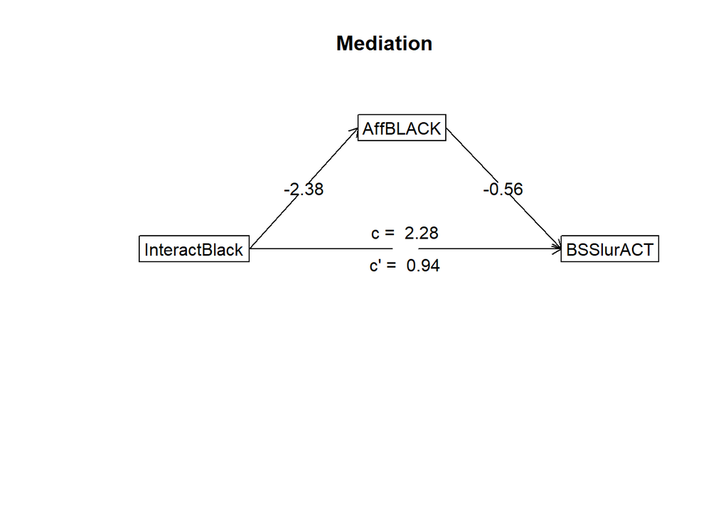

```r
mediate("BSSlurACT", "InteractBlack", "AffBLACK", contact)
```

**Output**

```
##
## Mediation/Moderation Analysis
## Call: mediate(y = "BSSlurACT", x = "InteractBlack", m = "AffBLACK",
##     data = contact)
##
## The DV (Y) was  BSSlurACT . The IV (X) was  InteractBlack . The mediating variable(s) =  AffBLACK .
##
## Total effect(c) of  InteractBlack  on  BSSlurACT  =  2.28   S.E. =  0.72  t  =  3.16  df=  215   with p =  0.0018
## Direct effect (c') of  InteractBlack  on  BSSlurACT  removing  AffBLACK  =  0.94   S.E. =  0.71  t  =  1.33  df=  214   with p =  0.19
## Indirect effect (ab) of  InteractBlack  on  BSSlurACT  through  AffBLACK   =  1.34
## Mean bootstrapped indirect effect =  1.37  with standard error =  0.37  Lower CI =  0.74    Upper CI =  2.2
## R = 0.42 R2 = 0.17   F = 22.4 on 2 and 214 DF   p-value:  1.19e-12
##
##  To see the longer output, specify short = FALSE in the print statement or ask for the summary
```

## Wrapping up

Click on Knit above to run all code and save the document as an HTML report that you can easily save and share. Note than you can only do that if all your code works without throwing an error - if there are just a few stubborn lines, you can always disable them for knitting by putting # in front of them.